# Categorical class 4

# Packages

```r
library(Stat2Data)      # Amyloid data
library(dplyr)          # data manipulation
library(ggplot2)        # plots
theme_set(theme_classic(base_size = 16)) # Set ggplot theme and increase font
library(nnet)           # multinomial logistic regression
library(MASS)           # ordinal logistic regression
library(broom)          # tidy model outputs
library(kableExtra)     # prettier tables
```

# Data

- **Stat2Data** package: [info here](https://cran.r-project.org/web/packages/Stat2Data/index.html)
  - `Amyloid` dataset: Amyloid-$\beta$ and cognitive impairment for a sample of $n$ = 57 Catholic priests
    - `Abeta`: Amount of amyloid-$\beta$ from the posterior cingulate cortex (pmol/g tissue)
    - `Group`: Level of cognitive impairment
      - `mAD` = Alzheimer’s disease
      - `MCI` = Mild cognitive impairment
      - `NCI` = No cognitive impairment

```r
library(Stat2Data)
data(Amyloid)
head(Amyloid)
```

```
  Group Abeta
1   NCI   114
2   NCI    41
3   NCI   276
4   NCI     0
5   NCI    16
6   NCI   228
```

## Plot

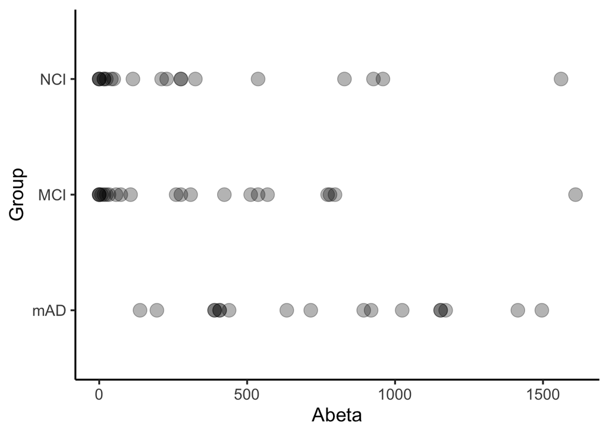

```r
ggplot(data = Amyloid, aes(x = Abeta, y = Group)) +
    geom_point(alpha = 0.3, size = 5)
```

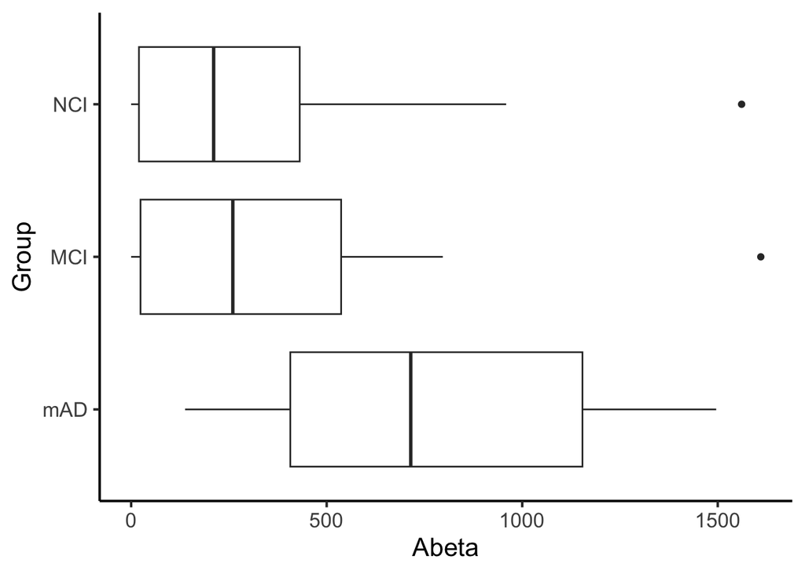

```r
ggplot(data = Amyloid, aes(x = Group, y = Abeta)) +
    geom_boxplot() +
    coord_flip()
```

- You can see a few broad things
  - The mean / median `Abeta` for the Alzheimer’s group is higher than the other groups
  - The people with near 0 `Abeta` are all in the no and mild cognitive impairment groups
- [Here’s](https://www.science.org/content/blog-post/faked-beta-amyloid-data-what-does-it-mean) some info on the faked data from some studies of amyloid and Alzheimer’s
  - The amyloid hypothesis of Alzheimer’s hasn’t been thrown out
  - Much of the science that wasn’t conducted by that one person still seems solid

# Multinomial logistic regression

- `multinom()` function in the **nnet** package
  - Specifying the model is basically the same as `lm()`
  - `Group ~ Abeta`: `Group` is predicted by `Abeta`
  - `data = Amyloid`: Specifies the dataset

```r
mult_m1 <- multinom(Group ~ Abeta, data = Amyloid)
summary(mult_m1)
```

```
Call:
multinom(formula = Group ~ Abeta, data = Amyloid)

Coefficients:
    (Intercept)        Abeta
MCI    1.319761 -0.002092564
NCI    1.231750 -0.002128210

Std. Errors:
    (Intercept)        Abeta
MCI   0.5583894 0.0008282646
NCI   0.5666824 0.0008558914

Residual Deviance: 114.6366
AIC: 122.6366
```

## Significance testing

### Test statistics and $p$-values

- Calculate $z$-statistics as estimate / standard error
  - Both estimates and standard errors are in the output
  - `coefficients` object and `standard.errors` object

```r
z_mult <- summary(mult_m1)$coefficients / summary(mult_m1)$standard.errors
z_mult
```

```
    (Intercept)     Abeta
MCI    2.363514 -2.526444
NCI    2.173617 -2.486542
```

- Calculate the $p$-values for those $z$-statistics
  - `pnorm()` takes a value from a normal distribution (here, a $z$-statistic, so mean = 0 and standard deviation = 1) and gives the probability to the **right** of that value (because of the `lower.tail = FALSE` option)
  - Then multiply by $2$ because it’s 2-tailed

```r
p_mult <- pnorm(abs(z_mult), 0, 1, lower.tail = FALSE) * 2
p_mult
```

```
    (Intercept)      Abeta
MCI  0.01810253 0.01152236
NCI  0.02973394 0.01289913
```

### Confidence intervals

- You can also use the confidence limits instead of or in addition to $p$-values

```r
ci_mult <- confint(mult_m1)
ci_mult
```

```
, , MCI

                   2.5 %        97.5 %
(Intercept)  0.225338176  2.4141845183
Abeta       -0.003715933 -0.0004691957

, , NCI

                   2.5 %        97.5 %
(Intercept)  0.121073156  2.3424272167
Abeta       -0.003805726 -0.0004506937
```

## Equations

- Interpret as in binary logistic regression
  - Just be careful about what you’re actually comparing: It’s more complicated than “event” vs “no event” here

### Logit metric

$$ln\left(\frac{\hat{p}_{MCI}}{\hat{p}_{mAD}}\right) = b_{0,MCI.mAD} + b_{1,MCI.mAD} (Abeta) = 1.32 + -0.00209 (Abeta)$$

$$ln\left(\frac{\hat{p}_{NCI}}{\hat{p}_{mAD}}\right) = b_{0,NCI.mAD} + b_{1,NCI.mAD} (Abeta) = 1.23 + -0.00213 (Abeta)$$

### Odds metric

$$\frac{\hat{p}_{MCI}}{\hat{p}_{mAD}} = e^{b_{0,MCI.mAD} + b_{1,MCI.mAD} (Abeta)} = e^{1.32 + -0.00209 (Abeta)}$$

$$\frac{\hat{p}_{NCI}}{\hat{p}_{mAD}} = e^{b_{0,NCI.mAD} + b_{1,NCI.mAD} (Abeta)} = e^{1.23 + -0.00213 (Abeta)}$$

### Probability metric

- Remember how these probabilities work
  - First equation: Probability of `MCI` vs `mAD` ONLY (ignore `NCI`)
  - Second equation: Probability of `NCI` vs `mAD` ONLY (ignore `MCI`)

$$\hat{p}_{MCI} = \frac{e^{b_{0,MCI.mAD} + b_{1,MCI.mAD} (Abeta)}}{1 + e^{b_{0,MCI.mAD} + b_{1,MCI.mAD} (Abeta)}} = \frac{e^{1.32 + -0.00209 (Abeta)}}{1 + e^{1.32 + -0.00209 (Abeta)}}$$

$$\hat{p}_{NCI} = \frac{e^{b_{0,NCI.mAD} + b_{1,NCI.mAD} (Abeta)}}{1 + e^{b_{0,NCI.mAD} + b_{1,NCI.mAD} (Abeta)}} = \frac{e^{1.23 + -0.00213 (Abeta)}}{1 + e^{1.23 + -0.00213 (Abeta)}}$$

# Ordinal logistic regression

- `polr()` function in the **MASS** package
  - `polr` = “proportional odds logistic regression”
  - Specifying the model is basically the same as `lm()`
  - `Group ~ Abeta`: `Group` is predicted by `Abeta`
  - `data = Amyloid`: Specifies the dataset
  - `Hess = TRUE` produces the *Hessian matrix*, which is used to calculate *standard errors*

```r
ord_m1 <- polr(Group ~ Abeta, data = Amyloid, Hess = TRUE)
summary(ord_m1)
```

```
Call:
polr(formula = Group ~ Abeta, data = Amyloid, Hess = TRUE)

Coefficients:
          Value Std. Error t value
Abeta -0.001671  0.0006333  -2.639

Intercepts:
        Value   Std. Error t value
mAD|MCI -1.6689  0.4323    -3.8602
MCI|NCI  0.0729  0.3618     0.2014

Residual Deviance: 116.6483
AIC: 122.6483
```

## Significance testing

### Test statisticss and $p$-values

- Get the coefficients from the `summary`
  - `coefficients` object

```r
z_ord <- summary(ord_m1)$coefficients
z_ord
```

```
              Value  Std. Error    t value
Abeta   -0.00167110 0.000633338 -2.6385589
mAD|MCI -1.66885689 0.432325739 -3.8601840
MCI|NCI  0.07286532 0.361800873  0.2013962
```

- Calculate the $p$-values for those $z$-statistics
  - `pnorm()` takes a value from a normal distribution (here, a $z$-statistic, so mean = 0 and standard deviation = 1) and gives the probability to the **right** of that value (because of the `lower.tail = FALSE` option)
  - Then multiply by $2$ because it’s 2-tailed

```r
p_ord <- pnorm(abs(z_ord[, "t value"]), 0, 1, lower.tail = FALSE) * 2
p_ord
```

```
       Abeta      mAD|MCI      MCI|NCI
0.0083259245 0.0001133017 0.8403887912
```

### Confidence intervals

- You can also use the confidence limits instead of or in addition to $p$-values
  - For this model, you only get CIs for the slope(s), not the intercepts

```r
ci_ord <- confint(ord_m1)
ci_ord
```

```
       2.5 %       97.5 %
-0.002961670 -0.000509697
```

## Equations

**Warning**

- Remember to flip the sign of the **slopes** in this model

### Logit metric

$$ln\left(\frac{\hat{p}_{mAD}}{\hat{p}_{MCI} + \hat{p}_{NCI}}\right) = b_{0,mAD} + -b_{1} Abeta = -1.67 + 0.00167 Abeta$$

$$ln\left(\frac{\hat{p}_{mAD} + \hat{p}_{MCI}}{\hat{p}_{NCI}}\right) = b_{0,MCI+mAD} + -b_{1} Abeta = 0.0729 + 0.00167 Abeta$$

### Odds metric

$$\frac{\hat{p}_{mAD}}{\hat{p}_{MCI} + \hat{p}_{NCI}} = e^{b_{0,mAD} + -b_{1} Abeta} = e^{-1.67 + 0.00167 Abeta}$$

$$\frac{\hat{p}_{mAD} + \hat{p}_{MCI}}{\hat{p}_{NCI}} = e^{b_{0,MCI+mAD} + -b_{1} Abeta} = e^{0.0729 + 0.00167 Abeta}$$

### Probability metric

- Remember how these probabilities work
  - First equation: Probability of `mAD` vs all higher (i.e., `MCI` and `NCI`)
  - Second equation: Probability of `mAD` and `MCI` vs all higher (i.e., `NCI`)

$$\hat{p}_{mAD} = \frac{e^{b_{0,mAD} + -b_{1} Abeta}}{1 + e^{b_{0,mAD} + -b_{1} Abeta}} = \frac{e^{-1.67 + 0.00167 Abeta}}{1 + e^{-1.67 + 0.00167 Abeta}}$$

$$\hat{p}_{mAD} + \hat{p}_{MCI} = \frac{e^{b_{0,MCI+mAD} + -b_{1} Abeta}}{1 + e^{b_{0,MCI+mAD} + -b_{1} Abeta}} = \frac{e^{0.0729 + 0.00167 Abeta}}{1 + e^{0.0729 + 0.00167 Abeta}}$$

## Tests of proportional odds

### Likelihood ratio test

- Compare multinomial logistic regression to ordinal logistic regression

```r
dev_mult <- deviance(mult_m1)
dev_mult
```

```
[1] 114.6366
```

```r
dev_ord  <- deviance(ord_m1)
dev_ord
```

```
[1] 116.6483
```

```r
LR_test <- dev_ord - dev_mult
LR_test
```

```
[1] 2.01166
```

```r
LR_p <- pchisq(LR_test,1,lower.tail = FALSE)
LR_p
```

```
[1] 0.1560944
```

- $\chi^2(1) = 2.012, p = 0.156$
  - Test is NS, so the models are **not significantly different**
  - So use the simpler model $\rightarrow$ *ordinal*

## Split data and run logistic regressions on every split

- Split data into 0,1 variables for every threshold
  - `split1` = `mAD` vs all higher categories
  - `split2` = `mAD` and `MCI` vs all higher categories
- There are other ways to do this, but I use `mutate()` and some nested `ifelse()` statements
  - `mutate` creates a new variable (`split1` and `split2`)
  - `ifelse` does one thing if the statement is true, another if it’s false
    - If `Group == "mAD"` then recode `split1` to 1
    - If not, then recode `split1` to 0
    - Several nested `ifelse` statements means it goes through all the options and recodes accordingly

```r
Amyloid <- Amyloid %>%
    mutate(split1 = ifelse(Group == "mAD", 1,
                           ifelse(Group == "MCI", 0,
                                  ifelse(Group == "NCI", 0, 0))))
Amyloid <- Amyloid %>%
    mutate(split2 = ifelse(Group == "mAD", 1,
                           ifelse(Group == "MCI", 1,
                                  ifelse(Group == "NCI", 0, 0))))
```

- Run logistic regressions with `split1` and `split2` as outcomes
  - Combine the results into a single table, `prop_odds`
    - Using the `tidy()` function from the **broom** package
  - Print a nicely formatted table using `kable()` from the **kableExtra** package
    - I like that it’s easy to format and select number of decimal places

```r
m1 <- glm(split1 ~ Abeta, Amyloid, family = binomial(link = "logit"))
m2 <- glm(split2 ~ Abeta, Amyloid, family = binomial(link = "logit"))
prop_odds <- cbind(tidy(m1)[2,1:2], tidy(m2)[2,2])
kable(prop_odds, digits = 3, row.names = F)
```

| term | estimate | estimate |
| --- | --- | --- |
| Abeta | 0.002 | 0.001 |

- Estimates are very similar across the two models, indicating that the proportional odds assumption is plausible